# Risk Factor Analysis

## Outcome Variable

**Outcome Variable:** haz

## Predictor Variables

**Intervention Variable:** enstunt

**Adjustment Set:**

unadjusted

## Stratifying Variables

The analysis was stratified on these variable(s):

- agecat
- studyid
- country

## Data Summary

| agecat | studyid | country | enstunt | n_cell | n |
| --- | --- | --- | --- | --- | --- |
| Birth | CMC-V-BCS-2002 | INDIA | 0 | 75 | 92 |
| Birth | CMC-V-BCS-2002 | INDIA | 1 | 17 | 92 |
| Birth | CMIN | BANGLADESH | 0 | 17 | 26 |
| Birth | CMIN | BANGLADESH | 1 | 9 | 26 |
| Birth | COHORTS | GUATEMALA | 0 | 802 | 852 |
| Birth | COHORTS | GUATEMALA | 1 | 50 | 852 |
| Birth | COHORTS | INDIA | 0 | 5848 | 6640 |
| Birth | COHORTS | INDIA | 1 | 792 | 6640 |
| Birth | COHORTS | PHILIPPINES | 0 | 2863 | 3050 |
| Birth | COHORTS | PHILIPPINES | 1 | 187 | 3050 |
| Birth | CONTENT | PERU | 0 | 2 | 2 |
| Birth | CONTENT | PERU | 1 | 0 | 2 |
| Birth | EE | PAKISTAN | 0 | 140 | 240 |
| Birth | EE | PAKISTAN | 1 | 100 | 240 |
| Birth | GMS-Nepal | NEPAL | 0 | 574 | 696 |
| Birth | GMS-Nepal | NEPAL | 1 | 122 | 696 |
| Birth | IRC | INDIA | 0 | 343 | 388 |
| Birth | IRC | INDIA | 1 | 45 | 388 |
| Birth | Keneba | GAMBIA | 0 | 1460 | 1543 |
| Birth | Keneba | GAMBIA | 1 | 83 | 1543 |
| Birth | MAL-ED | BANGLADESH | 0 | 187 | 231 |
| Birth | MAL-ED | BANGLADESH | 1 | 44 | 231 |
| Birth | MAL-ED | BRAZIL | 0 | 56 | 65 |
| Birth | MAL-ED | BRAZIL | 1 | 9 | 65 |
| Birth | MAL-ED | INDIA | 0 | 37 | 47 |
| Birth | MAL-ED | INDIA | 1 | 10 | 47 |
| Birth | MAL-ED | NEPAL | 0 | 25 | 27 |
| Birth | MAL-ED | NEPAL | 1 | 2 | 27 |
| Birth | MAL-ED | PERU | 0 | 207 | 233 |
| Birth | MAL-ED | PERU | 1 | 26 | 233 |

[output cut: 122 more lines]

The following strata were considered:

- agecat: 24 months, studyid: CMC-V-BCS-2002, country: INDIA
- agecat: 24 months, studyid: CMIN, country: BANGLADESH
- agecat: 24 months, studyid: COHORTS, country: GUATEMALA
- agecat: 24 months, studyid: COHORTS, country: INDIA
- agecat: 24 months, studyid: COHORTS, country: PHILIPPINES
- agecat: 24 months, studyid: CONTENT, country: PERU
- agecat: 24 months, studyid: EE, country: PAKISTAN
- agecat: 24 months, studyid: GMS-Nepal, country: NEPAL
- agecat: 24 months, studyid: IRC, country: INDIA
- agecat: 24 months, studyid: Keneba, country: GAMBIA
- agecat: 24 months, studyid: LCNI-5, country: MALAWI
- agecat: 24 months, studyid: MAL-ED, country: BANGLADESH
- agecat: 24 months, studyid: MAL-ED, country: BRAZIL
- agecat: 24 months, studyid: MAL-ED, country: INDIA
- agecat: 24 months, studyid: MAL-ED, country: NEPAL
- agecat: 24 months, studyid: MAL-ED, country: PERU
- agecat: 24 months, studyid: MAL-ED, country: SOUTH AFRICA
- agecat: 24 months, studyid: MAL-ED, country: TANZANIA, UNITED REPUBLIC OF
- agecat: 24 months, studyid: NIH-Birth, country: BANGLADESH
- agecat: 24 months, studyid: NIH-Crypto, country: BANGLADESH
- agecat: 24 months, studyid: PROBIT, country: BELARUS
- agecat: 24 months, studyid: PROVIDE, country: BANGLADESH
- agecat: 24 months, studyid: TanzaniaChild2, country: TANZANIA, UNITED REPUBLIC OF
- agecat: 24 months, studyid: ZVITAMBO, country: ZIMBABWE
- agecat: 6 months, studyid: CMC-V-BCS-2002, country: INDIA
- agecat: 6 months, studyid: CMIN, country: BANGLADESH
- agecat: 6 months, studyid: COHORTS, country: GUATEMALA
- agecat: 6 months, studyid: COHORTS, country: INDIA
- agecat: 6 months, studyid: COHORTS, country: PHILIPPINES
- agecat: 6 months, studyid: CONTENT, country: PERU
- agecat: 6 months, studyid: EE, country: PAKISTAN
- agecat: 6 months, studyid: GMS-Nepal, country: NEPAL
- agecat: 6 months, studyid: Guatemala BSC, country: GUATEMALA
- agecat: 6 months, studyid: IRC, country: INDIA
- agecat: 6 months, studyid: Keneba, country: GAMBIA
- agecat: 6 months, studyid: LCNI-5, country: MALAWI
- agecat: 6 months, studyid: MAL-ED, country: BANGLADESH
- agecat: 6 months, studyid: MAL-ED, country: BRAZIL
- agecat: 6 months, studyid: MAL-ED, country: INDIA
- agecat: 6 months, studyid: MAL-ED, country: NEPAL
- agecat: 6 months, studyid: MAL-ED, country: PERU
- agecat: 6 months, studyid: MAL-ED, country: SOUTH AFRICA
- agecat: 6 months, studyid: MAL-ED, country: TANZANIA, UNITED REPUBLIC OF
- agecat: 6 months, studyid: NIH-Birth, country: BANGLADESH
- agecat: 6 months, studyid: NIH-Crypto, country: BANGLADESH
- agecat: 6 months, studyid: PROBIT, country: BELARUS
- agecat: 6 months, studyid: PROVIDE, country: BANGLADESH
- agecat: 6 months, studyid: ResPak, country: PAKISTAN
- agecat: 6 months, studyid: SAS-CompFeed, country: INDIA
- agecat: 6 months, studyid: SAS-FoodSuppl, country: INDIA
- agecat: 6 months, studyid: TanzaniaChild2, country: TANZANIA, UNITED REPUBLIC OF
- agecat: 6 months, studyid: ZVITAMBO, country: ZIMBABWE
- agecat: Birth, studyid: CMC-V-BCS-2002, country: INDIA
- agecat: Birth, studyid: CMIN, country: BANGLADESH
- agecat: Birth, studyid: COHORTS, country: GUATEMALA
- agecat: Birth, studyid: COHORTS, country: INDIA
- agecat: Birth, studyid: COHORTS, country: PHILIPPINES
- agecat: Birth, studyid: CONTENT, country: PERU
- agecat: Birth, studyid: EE, country: PAKISTAN
- agecat: Birth, studyid: GMS-Nepal, country: NEPAL
- agecat: Birth, studyid: IRC, country: INDIA
- agecat: Birth, studyid: Keneba, country: GAMBIA
- agecat: Birth, studyid: MAL-ED, country: BANGLADESH
- agecat: Birth, studyid: MAL-ED, country: BRAZIL
- agecat: Birth, studyid: MAL-ED, country: INDIA
- agecat: Birth, studyid: MAL-ED, country: NEPAL
- agecat: Birth, studyid: MAL-ED, country: PERU
- agecat: Birth, studyid: MAL-ED, country: SOUTH AFRICA
- agecat: Birth, studyid: MAL-ED, country: TANZANIA, UNITED REPUBLIC OF
- agecat: Birth, studyid: NIH-Birth, country: BANGLADESH
- agecat: Birth, studyid: NIH-Crypto, country: BANGLADESH
- agecat: Birth, studyid: PROBIT, country: BELARUS
- agecat: Birth, studyid: PROVIDE, country: BANGLADESH
- agecat: Birth, studyid: ResPak, country: PAKISTAN
- agecat: Birth, studyid: SAS-CompFeed, country: INDIA
- agecat: Birth, studyid: ZVITAMBO, country: ZIMBABWE

### Dropped Strata

Some strata were dropped due to rare outcomes:

- agecat: Birth, studyid: CONTENT, country: PERU
- agecat: Birth, studyid: MAL-ED, country: NEPAL
- agecat: 24 months, studyid: TanzaniaChild2, country: TANZANIA, UNITED REPUBLIC OF

## Methods Detail

We’re interested in the causal parameters $E[Y_a]$ for all values of $a \in \mathcal{A}$. These parameters represent the mean outcome if, possibly contrary to fact, we intervened to set all units to have $A=a$. Under the randomization and positivity assumptions, these are identified by the statistical parameters $\psi_a=E_W[E_{Y|A,W}(Y|A=a,W)]$. In addition, we’re interested in the mean of $Y$, $E[Y]$ under no intervention (the observed mean). We will estimate these parameters by using SuperLearner to fit the relevant likelihood factors – $E_{Y|A,W}(Y|A=a,W)$ and $p(A=a|W)$, and then updating our likelihood fit using a joint TMLE.

For unadjusted analyses ($W=\{\}$), initial likelihoods were estimated using Lrnr_glm to estimate the simple $E(Y|A)$ and Lrnr_mean to estimate $p(A)$. For adjusted analyses, a small library containing Lrnr_glmnet, Lrnr_xgboost, and Lrnr_mean was used.

Having estimated these parameters, we will then use the delta method to estimate relative risks and attributable risks relative to a prespecified baseline level of $A$.

# Results Detail

## Results Plots

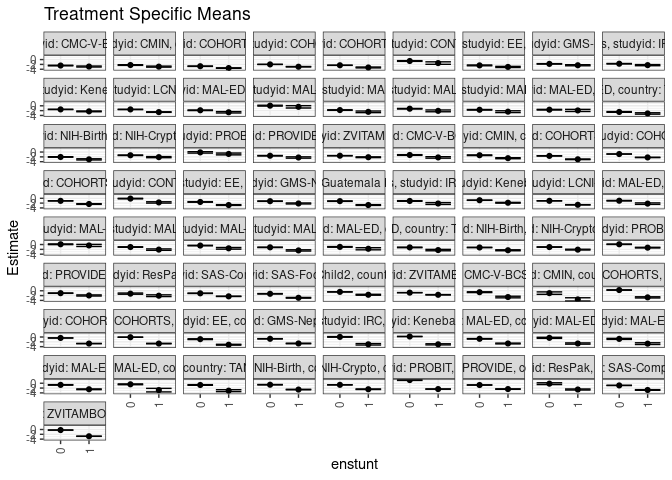

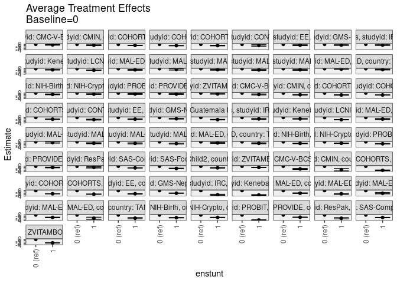

[figure not shown]

## Results Table

### Parameter: TSM

| agecat | studyid | country | intervention_level | baseline_level | estimate | ci_lower | ci_upper |
| --- | --- | --- | --- | --- | --- | --- | --- |
| Birth | CMC-V-BCS-2002 | INDIA | 0 | NA | -0.5899333 | -0.7524851 | -0.4273816 |
| Birth | CMC-V-BCS-2002 | INDIA | 1 | NA | -2.5991176 | -2.9257247 | -2.2725106 |
| Birth | CMIN | BANGLADESH | 0 | NA | -0.9811765 | -1.4828326 | -0.4795203 |
| Birth | CMIN | BANGLADESH | 1 | NA | -3.5811111 | -4.2641379 | -2.8980843 |
| Birth | COHORTS | GUATEMALA | 0 | NA | 0.3083042 | 0.2366931 | 0.3799154 |
| Birth | COHORTS | GUATEMALA | 1 | NA | -2.7346000 | -2.9701783 | -2.4990217 |
| Birth | COHORTS | INDIA | 0 | NA | -0.3925051 | -0.4161172 | -0.3688931 |
| Birth | COHORTS | INDIA | 1 | NA | -2.7181061 | -2.7653506 | -2.6708615 |
| Birth | COHORTS | PHILIPPINES | 0 | NA | -0.0878589 | -0.1212465 | -0.0544713 |
| Birth | COHORTS | PHILIPPINES | 1 | NA | -2.7168984 | -2.8178064 | -2.6159904 |
| Birth | EE | PAKISTAN | 0 | NA | -0.8982143 | -1.0576596 | -0.7387690 |
| Birth | EE | PAKISTAN | 1 | NA | -3.2086000 | -3.3880121 | -3.0291879 |
| Birth | GMS-Nepal | NEPAL | 0 | NA | -0.7458362 | -0.8120213 | -0.6796512 |
| Birth | GMS-Nepal | NEPAL | 1 | NA | -2.6816393 | -2.7999479 | -2.5633308 |
| Birth | IRC | INDIA | 0 | NA | 0.0484548 | -0.0897334 | 0.1866430 |
| Birth | IRC | INDIA | 1 | NA | -3.0253333 | -3.3364760 | -2.7141906 |
| Birth | Keneba | GAMBIA | 0 | NA | 0.2047260 | 0.1512077 | 0.2582443 |
| Birth | Keneba | GAMBIA | 1 | NA | -3.0285542 | -3.2639390 | -2.7931694 |
| Birth | MAL-ED | BANGLADESH | 0 | NA | -0.7490909 | -0.8554669 | -0.6427149 |
| Birth | MAL-ED | BANGLADESH | 1 | NA | -2.6863636 | -2.8519345 | -2.5207928 |
| Birth | MAL-ED | BRAZIL | 0 | NA | -0.3512500 | -0.5701451 | -0.1323549 |
| Birth | MAL-ED | BRAZIL | 1 | NA | -2.6966667 | -2.9574559 | -2.4358775 |
| Birth | MAL-ED | INDIA | 0 | NA | -0.7843243 | -0.9905632 | -0.5780855 |
| Birth | MAL-ED | INDIA | 1 | NA | -2.7550000 | -3.1126874 | -2.3973126 |
| Birth | MAL-ED | PERU | 0 | NA | -0.6803865 | -0.7815718 | -0.5792012 |
| Birth | MAL-ED | PERU | 1 | NA | -2.4942308 | -2.6445917 | -2.3438699 |
| Birth | MAL-ED | SOUTH AFRICA | 0 | NA | -0.4356637 | -0.5900771 | -0.2812503 |
| Birth | MAL-ED | SOUTH AFRICA | 1 | NA | -2.8470000 | -3.5794433 | -2.1145567 |
| Birth | MAL-ED | TANZANIA, UNITED REPUBLIC OF | 0 | NA | -0.7222549 | -0.8603157 | -0.5841941 |
| Birth | MAL-ED | TANZANIA, UNITED REPUBLIC OF | 1 | NA | -3.0773913 | -3.4834290 | -2.6713536 |

[output cut: 116 more lines]

### Parameter: E(Y)

| agecat | studyid | country | intervention_level | baseline_level | estimate | ci_lower | ci_upper |
| --- | --- | --- | --- | --- | --- | --- | --- |
| Birth | CMC-V-BCS-2002 | INDIA | NA | NA | -0.9611957 | -1.1776967 | -0.7446946 |
| Birth | CMIN | BANGLADESH | NA | NA | -1.8811538 | -2.5124807 | -1.2498270 |
| Birth | COHORTS | GUATEMALA | NA | NA | 0.1297300 | 0.0458017 | 0.2136584 |
| Birth | COHORTS | INDIA | NA | NA | -0.6698961 | -0.6980556 | -0.6417365 |
| Birth | COHORTS | PHILIPPINES | NA | NA | -0.2490492 | -0.2880580 | -0.2100404 |
| Birth | EE | PAKISTAN | NA | NA | -1.8608750 | -2.0482045 | -1.6735455 |
| Birth | GMS-Nepal | NEPAL | NA | NA | -1.0851580 | -1.1651811 | -1.0051350 |
| Birth | IRC | INDIA | NA | NA | -0.3080412 | -0.4687931 | -0.1472894 |
| Birth | Keneba | GAMBIA | NA | NA | 0.0308036 | -0.0328378 | 0.0944451 |
| Birth | MAL-ED | BANGLADESH | NA | NA | -1.1180952 | -1.2525408 | -0.9836496 |
| Birth | MAL-ED | BRAZIL | NA | NA | -0.6760000 | -0.9521457 | -0.3998543 |
| Birth | MAL-ED | INDIA | NA | NA | -1.2036170 | -1.4976814 | -0.9095527 |
| Birth | MAL-ED | PERU | NA | NA | -0.8827897 | -1.0001058 | -0.7654736 |
| Birth | MAL-ED | SOUTH AFRICA | NA | NA | -0.6317073 | -0.8249555 | -0.4384591 |
| Birth | MAL-ED | TANZANIA, UNITED REPUBLIC OF | NA | NA | -1.1556000 | -1.3655361 | -0.9456639 |
| Birth | NIH-Birth | BANGLADESH | NA | NA | -0.9310197 | -1.0197391 | -0.8423003 |
| Birth | NIH-Crypto | BANGLADESH | NA | NA | -0.9094945 | -0.9809370 | -0.8380521 |
| Birth | PROBIT | BELARUS | NA | NA | 1.3114417 | 1.1524752 | 1.4704082 |
| Birth | PROVIDE | BANGLADESH | NA | NA | -0.8851020 | -0.9601332 | -0.8100709 |
| Birth | ResPak | PAKISTAN | NA | NA | -0.9800000 | -1.4086438 | -0.5513562 |
| Birth | SAS-CompFeed | INDIA | NA | NA | -1.4314217 | -1.5099245 | -1.3529189 |
| Birth | ZVITAMBO | ZIMBABWE | NA | NA | -0.5002724 | -0.5208163 | -0.4797285 |
| 6 months | CMC-V-BCS-2002 | INDIA | NA | NA | -1.4234508 | -1.5645974 | -1.2823042 |
| 6 months | CMIN | BANGLADESH | NA | NA | -1.7844376 | -1.9222926 | -1.6465825 |
| 6 months | COHORTS | GUATEMALA | NA | NA | -1.8157336 | -1.8837688 | -1.7476985 |
| 6 months | COHORTS | INDIA | NA | NA | -0.9968455 | -1.0246180 | -0.9690730 |
| 6 months | COHORTS | PHILIPPINES | NA | NA | -1.1405724 | -1.1824954 | -1.0986493 |
| 6 months | CONTENT | PERU | NA | NA | -0.2785256 | -0.4098735 | -0.1471776 |
| 6 months | EE | PAKISTAN | NA | NA | -2.0835567 | -2.2027557 | -1.9643578 |
| 6 months | GMS-Nepal | NEPAL | NA | NA | -1.3508392 | -1.4290633 | -1.2726152 |
| 6 months | Guatemala BSC | GUATEMALA | NA | NA | -1.5619008 | -1.6727702 | -1.4510313 |
| 6 months | IRC | INDIA | NA | NA | -1.2344062 | -1.3658524 | -1.1029600 |
| 6 months | Keneba | GAMBIA | NA | NA | -0.9041369 | -0.9513363 | -0.8569376 |
| 6 months | LCNI-5 | MALAWI | NA | NA | -1.6601907 | -1.7297701 | -1.5906113 |
| 6 months | MAL-ED | BANGLADESH | NA | NA | -1.2049931 | -1.3222136 | -1.0877726 |
| 6 months | MAL-ED | BRAZIL | NA | NA | 0.0475758 | -0.0963508 | 0.1915023 |
| 6 months | MAL-ED | INDIA | NA | NA | -1.2115254 | -1.3298727 | -1.0931782 |
| 6 months | MAL-ED | NEPAL | NA | NA | -0.5615819 | -0.6741832 | -0.4489807 |
| 6 months | MAL-ED | PERU | NA | NA | -1.3236661 | -1.4316775 | -1.2156546 |
| 6 months | MAL-ED | SOUTH AFRICA | NA | NA | -1.0633202 | -1.1909180 | -0.9357224 |
| 6 months | MAL-ED | TANZANIA, UNITED REPUBLIC OF | NA | NA | -1.3687449 | -1.4907629 | -1.2467270 |
| 6 months | NIH-Birth | BANGLADESH | NA | NA | -1.4073821 | -1.4960598 | -1.3187043 |
| 6 months | NIH-Crypto | BANGLADESH | NA | NA | -1.1986783 | -1.2700937 | -1.1272630 |
| 6 months | PROBIT | BELARUS | NA | NA | 0.0980074 | 0.0062724 | 0.1897424 |
| 6 months | PROVIDE | BANGLADESH | NA | NA | -1.0916915 | -1.1661176 | -1.0172654 |
| 6 months | ResPak | PAKISTAN | NA | NA | -1.4314086 | -1.6374838 | -1.2253335 |
| 6 months | SAS-CompFeed | INDIA | NA | NA | -1.4018563 | -1.4810585 | -1.3226541 |
| 6 months | SAS-FoodSuppl | INDIA | NA | NA | -1.8986842 | -2.0118892 | -1.7854792 |
| 6 months | TanzaniaChild2 | TANZANIA, UNITED REPUBLIC OF | NA | NA | -0.5434389 | -0.5924056 | -0.4944722 |
| 6 months | ZVITAMBO | ZIMBABWE | NA | NA | -0.8679450 | -0.8935071 | -0.8423828 |
| 24 months | CMC-V-BCS-2002 | INDIA | NA | NA | -2.5588679 | -2.6583730 | -2.4593629 |
| 24 months | CMIN | BANGLADESH | NA | NA | -2.5109504 | -2.6361514 | -2.3857494 |
| 24 months | COHORTS | GUATEMALA | NA | NA | -2.9923738 | -3.0565851 | -2.9281626 |
| 24 months | COHORTS | INDIA | NA | NA | -2.1198201 | -2.1524299 | -2.0872104 |
| 24 months | COHORTS | PHILIPPINES | NA | NA | -2.4141145 | -2.4590818 | -2.3691473 |
| 24 months | CONTENT | PERU | NA | NA | -0.6868598 | -0.8388476 | -0.5348719 |
| 24 months | EE | PAKISTAN | NA | NA | -2.6699900 | -2.8138051 | -2.5261749 |
| 24 months | GMS-Nepal | NEPAL | NA | NA | -1.8874180 | -1.9728588 | -1.8019773 |
| 24 months | IRC | INDIA | NA | NA | -1.7987775 | -1.8923914 | -1.7051636 |
| 24 months | Keneba | GAMBIA | NA | NA | -1.5774356 | -1.6272400 | -1.5276311 |
| 24 months | LCNI-5 | MALAWI | NA | NA | -1.8861485 | -1.9671802 | -1.8051169 |
| 24 months | MAL-ED | BANGLADESH | NA | NA | -1.9783962 | -2.1050210 | -1.8517715 |
| 24 months | MAL-ED | BRAZIL | NA | NA | 0.0061144 | -0.1625850 | 0.1748138 |
| 24 months | MAL-ED | INDIA | NA | NA | -1.8861894 | -2.0110006 | -1.7613783 |
| 24 months | MAL-ED | NEPAL | NA | NA | -1.3075877 | -1.4270718 | -1.1881037 |
| 24 months | MAL-ED | PERU | NA | NA | -1.7524710 | -1.8736426 | -1.6312994 |
| 24 months | MAL-ED | SOUTH AFRICA | NA | NA | -1.6450595 | -1.7797240 | -1.5103950 |
| 24 months | MAL-ED | TANZANIA, UNITED REPUBLIC OF | NA | NA | -2.6455607 | -2.7807256 | -2.5103959 |
| 24 months | NIH-Birth | BANGLADESH | NA | NA | -2.2190579 | -2.3217459 | -2.1163699 |
| 24 months | NIH-Crypto | BANGLADESH | NA | NA | -1.4412646 | -1.5249156 | -1.3576135 |
| 24 months | PROBIT | BELARUS | NA | NA | -0.1442891 | -0.4253755 | 0.1367972 |
| 24 months | PROVIDE | BANGLADESH | NA | NA | -1.6024221 | -1.6857420 | -1.5191023 |
| 24 months | ZVITAMBO | ZIMBABWE | NA | NA | -1.6055701 | -1.6625562 | -1.5485840 |

### Parameter: ATE

| agecat | studyid | country | intervention_level | baseline_level | estimate | ci_lower | ci_upper |
| --- | --- | --- | --- | --- | --- | --- | --- |
| Birth | CMC-V-BCS-2002 | INDIA | 0 | 0 | 0.0000000 | 0.0000000 | 0.0000000 |
| Birth | CMC-V-BCS-2002 | INDIA | 1 | 0 | -2.0091843 | -2.3740065 | -1.6443621 |
| Birth | CMIN | BANGLADESH | 0 | 0 | 0.0000000 | 0.0000000 | 0.0000000 |
| Birth | CMIN | BANGLADESH | 1 | 0 | -2.5999346 | -3.4473923 | -1.7524770 |
| Birth | COHORTS | GUATEMALA | 0 | 0 | 0.0000000 | 0.0000000 | 0.0000000 |
| Birth | COHORTS | GUATEMALA | 1 | 0 | -3.0429042 | -3.2891263 | -2.7966822 |
| Birth | COHORTS | INDIA | 0 | 0 | 0.0000000 | 0.0000000 | 0.0000000 |
| Birth | COHORTS | INDIA | 1 | 0 | -2.3256009 | -2.3784174 | -2.2727845 |
| Birth | COHORTS | PHILIPPINES | 0 | 0 | 0.0000000 | 0.0000000 | 0.0000000 |
| Birth | COHORTS | PHILIPPINES | 1 | 0 | -2.6290395 | -2.7353276 | -2.5227514 |
| Birth | EE | PAKISTAN | 0 | 0 | 0.0000000 | 0.0000000 | 0.0000000 |
| Birth | EE | PAKISTAN | 1 | 0 | -2.3103857 | -2.5504097 | -2.0703617 |
| Birth | GMS-Nepal | NEPAL | 0 | 0 | 0.0000000 | 0.0000000 | 0.0000000 |
| Birth | GMS-Nepal | NEPAL | 1 | 0 | -1.9358031 | -2.0713663 | -1.8002400 |
| Birth | IRC | INDIA | 0 | 0 | 0.0000000 | 0.0000000 | 0.0000000 |
| Birth | IRC | INDIA | 1 | 0 | -3.0737881 | -3.4142375 | -2.7333388 |
| Birth | Keneba | GAMBIA | 0 | 0 | 0.0000000 | 0.0000000 | 0.0000000 |
| Birth | Keneba | GAMBIA | 1 | 0 | -3.2332802 | -3.4746725 | -2.9918880 |
| Birth | MAL-ED | BANGLADESH | 0 | 0 | 0.0000000 | 0.0000000 | 0.0000000 |
| Birth | MAL-ED | BANGLADESH | 1 | 0 | -1.9372727 | -2.1340710 | -1.7404744 |
| Birth | MAL-ED | BRAZIL | 0 | 0 | 0.0000000 | 0.0000000 | 0.0000000 |
| Birth | MAL-ED | BRAZIL | 1 | 0 | -2.3454167 | -2.6858959 | -2.0049374 |
| Birth | MAL-ED | INDIA | 0 | 0 | 0.0000000 | 0.0000000 | 0.0000000 |
| Birth | MAL-ED | INDIA | 1 | 0 | -1.9706757 | -2.3835615 | -1.5577898 |
| Birth | MAL-ED | PERU | 0 | 0 | 0.0000000 | 0.0000000 | 0.0000000 |
| Birth | MAL-ED | PERU | 1 | 0 | -1.8138443 | -1.9950814 | -1.6326072 |
| Birth | MAL-ED | SOUTH AFRICA | 0 | 0 | 0.0000000 | 0.0000000 | 0.0000000 |
| Birth | MAL-ED | SOUTH AFRICA | 1 | 0 | -2.4113363 | -3.1598793 | -1.6627933 |
| Birth | MAL-ED | TANZANIA, UNITED REPUBLIC OF | 0 | 0 | 0.0000000 | 0.0000000 | 0.0000000 |
| Birth | MAL-ED | TANZANIA, UNITED REPUBLIC OF | 1 | 0 | -2.3551364 | -2.7840040 | -1.9262688 |

[output cut: 116 more lines]

### Parameter: PAR

| agecat | studyid | country | intervention_level | baseline_level | estimate | ci_lower | ci_upper |
| --- | --- | --- | --- | --- | --- | --- | --- |
| Birth | CMC-V-BCS-2002 | INDIA | 0 | NA | -0.3712623 | -0.5450860 | -0.1974387 |
| Birth | CMIN | BANGLADESH | 0 | NA | -0.8999774 | -1.4666696 | -0.3332851 |
| Birth | COHORTS | GUATEMALA | 0 | NA | -0.1785742 | -0.2287510 | -0.1283974 |
| Birth | COHORTS | INDIA | 0 | NA | -0.2773910 | -0.2965856 | -0.2581963 |
| Birth | COHORTS | PHILIPPINES | 0 | NA | -0.1611903 | -0.1845066 | -0.1378740 |
| Birth | EE | PAKISTAN | 0 | NA | -0.9626607 | -1.1383172 | -0.7870042 |
| Birth | GMS-Nepal | NEPAL | 0 | NA | -0.3393218 | -0.3989783 | -0.2796653 |
| Birth | IRC | INDIA | 0 | NA | -0.3564960 | -0.4622064 | -0.2507857 |
| Birth | Keneba | GAMBIA | 0 | NA | -0.1739224 | -0.2125768 | -0.1352680 |
| Birth | MAL-ED | BANGLADESH | 0 | NA | -0.3690043 | -0.4742211 | -0.2637876 |
| Birth | MAL-ED | BRAZIL | 0 | NA | -0.3247500 | -0.5287356 | -0.1207644 |
| Birth | MAL-ED | INDIA | 0 | NA | -0.4192927 | -0.6683693 | -0.1702161 |
| Birth | MAL-ED | PERU | 0 | NA | -0.2024032 | -0.2786238 | -0.1261826 |
| Birth | MAL-ED | SOUTH AFRICA | 0 | NA | -0.1960436 | -0.3278706 | -0.0642166 |
| Birth | MAL-ED | TANZANIA, UNITED REPUBLIC OF | 0 | NA | -0.4333451 | -0.6123053 | -0.2543849 |
| Birth | NIH-Birth | BANGLADESH | 0 | NA | -0.3200608 | -0.3822525 | -0.2578692 |
| Birth | NIH-Crypto | BANGLADESH | 0 | NA | -0.2518242 | -0.3001968 | -0.2034515 |
| Birth | PROBIT | BELARUS | 0 | NA | -0.0091290 | -0.0148485 | -0.0034095 |
| Birth | PROVIDE | BANGLADESH | 0 | NA | -0.1488088 | -0.1904031 | -0.1072145 |
| Birth | ResPak | PAKISTAN | 0 | NA | -0.8060714 | -1.1814336 | -0.4307092 |
| Birth | SAS-CompFeed | INDIA | 0 | NA | -0.5257185 | -0.5968685 | -0.4545685 |
| Birth | ZVITAMBO | ZIMBABWE | 0 | NA | -0.2660951 | -0.2798994 | -0.2522909 |
| 6 months | CMC-V-BCS-2002 | INDIA | 0 | NA | -0.2059054 | -0.2865894 | -0.1252214 |
| 6 months | CMIN | BANGLADESH | 0 | NA | -0.4641285 | -0.5831827 | -0.3450743 |
| 6 months | COHORTS | GUATEMALA | 0 | NA | -0.2224580 | -0.2631566 | -0.1817593 |
| 6 months | COHORTS | INDIA | 0 | NA | -0.1657426 | -0.1804014 | -0.1510839 |
| 6 months | COHORTS | PHILIPPINES | 0 | NA | -0.0753765 | -0.0899896 | -0.0607633 |
| 6 months | CONTENT | PERU | 0 | NA | -0.1469871 | -0.2145967 | -0.0793775 |
| 6 months | EE | PAKISTAN | 0 | NA | -0.5620496 | -0.6733281 | -0.4507711 |
| 6 months | GMS-Nepal | NEPAL | 0 | NA | -0.1543734 | -0.1991314 | -0.1096155 |
| 6 months | Guatemala BSC | GUATEMALA | 0 | NA | -0.3843204 | -0.4733370 | -0.2953037 |
| 6 months | IRC | INDIA | 0 | NA | -0.1278653 | -0.1870066 | -0.0687240 |
| 6 months | Keneba | GAMBIA | 0 | NA | -0.0984758 | -0.1190607 | -0.0778908 |
| 6 months | LCNI-5 | MALAWI | 0 | NA | -0.6042284 | -0.6673857 | -0.5410711 |
| 6 months | MAL-ED | BANGLADESH | 0 | NA | -0.1939782 | -0.2707119 | -0.1172446 |
| 6 months | MAL-ED | BRAZIL | 0 | NA | -0.0593174 | -0.1187944 | 0.0001597 |
| 6 months | MAL-ED | INDIA | 0 | NA | -0.1711551 | -0.2424057 | -0.0999044 |
| 6 months | MAL-ED | NEPAL | 0 | NA | -0.1359489 | -0.1991357 | -0.0727621 |
| 6 months | MAL-ED | PERU | 0 | NA | -0.1590391 | -0.2201472 | -0.0979310 |
| 6 months | MAL-ED | SOUTH AFRICA | 0 | NA | -0.0832248 | -0.1395200 | -0.0269296 |
| 6 months | MAL-ED | TANZANIA, UNITED REPUBLIC OF | 0 | NA | -0.1734565 | -0.2440116 | -0.1029014 |
| 6 months | NIH-Birth | BANGLADESH | 0 | NA | -0.1818861 | -0.2313773 | -0.1323949 |
| 6 months | NIH-Crypto | BANGLADESH | 0 | NA | -0.1534662 | -0.1909170 | -0.1160155 |
| 6 months | PROBIT | BELARUS | 0 | NA | -0.0103445 | -0.0164574 | -0.0042316 |
| 6 months | PROVIDE | BANGLADESH | 0 | NA | -0.0962741 | -0.1291849 | -0.0633632 |
| 6 months | ResPak | PAKISTAN | 0 | NA | -0.2353104 | -0.3641056 | -0.1065152 |
| 6 months | SAS-CompFeed | INDIA | 0 | NA | -0.3401690 | -0.3809527 | -0.2993854 |
| 6 months | SAS-FoodSuppl | INDIA | 0 | NA | -0.6457101 | -0.7502670 | -0.5411532 |
| 6 months | TanzaniaChild2 | TANZANIA, UNITED REPUBLIC OF | 0 | NA | -0.0819931 | -0.1004793 | -0.0635070 |
| 6 months | ZVITAMBO | ZIMBABWE | 0 | NA | -0.0897352 | -0.1000028 | -0.0794677 |
| 24 months | CMC-V-BCS-2002 | INDIA | 0 | NA | -0.0872466 | -0.1395348 | -0.0349584 |
| 24 months | CMIN | BANGLADESH | 0 | NA | -0.2435648 | -0.3452297 | -0.1418999 |
| 24 months | COHORTS | GUATEMALA | 0 | NA | -0.2377928 | -0.2819681 | -0.1936174 |
| 24 months | COHORTS | INDIA | 0 | NA | -0.1165343 | -0.1309058 | -0.1021629 |
| 24 months | COHORTS | PHILIPPINES | 0 | NA | -0.0507466 | -0.0635700 | -0.0379231 |
| 24 months | CONTENT | PERU | 0 | NA | -0.0886285 | -0.1564732 | -0.0207837 |
| 24 months | EE | PAKISTAN | 0 | NA | -0.2590734 | -0.3833198 | -0.1348269 |
| 24 months | GMS-Nepal | NEPAL | 0 | NA | -0.0951069 | -0.1388118 | -0.0514019 |
| 24 months | IRC | INDIA | 0 | NA | -0.0725857 | -0.1085280 | -0.0366434 |
| 24 months | Keneba | GAMBIA | 0 | NA | -0.0818381 | -0.1025105 | -0.0611656 |
| 24 months | LCNI-5 | MALAWI | 0 | NA | -0.3861618 | -0.4527192 | -0.3196044 |
| 24 months | MAL-ED | BANGLADESH | 0 | NA | -0.1283962 | -0.1921427 | -0.0646497 |
| 24 months | MAL-ED | BRAZIL | 0 | NA | -0.0545078 | -0.1170174 | 0.0080017 |
| 24 months | MAL-ED | INDIA | 0 | NA | -0.1158491 | -0.1821611 | -0.0495371 |
| 24 months | MAL-ED | NEPAL | 0 | NA | -0.1052743 | -0.1650878 | -0.0454608 |
| 24 months | MAL-ED | PERU | 0 | NA | -0.1047219 | -0.1689107 | -0.0405332 |
| 24 months | MAL-ED | SOUTH AFRICA | 0 | NA | -0.0309045 | -0.0781527 | 0.0163436 |
| 24 months | MAL-ED | TANZANIA, UNITED REPUBLIC OF | 0 | NA | -0.0951464 | -0.1530339 | -0.0372589 |
| 24 months | NIH-Birth | BANGLADESH | 0 | NA | -0.1685767 | -0.2263592 | -0.1107941 |
| 24 months | NIH-Crypto | BANGLADESH | 0 | NA | -0.1056114 | -0.1462939 | -0.0649290 |
| 24 months | PROBIT | BELARUS | 0 | NA | -0.0021020 | -0.0144217 | 0.0102177 |
| 24 months | PROVIDE | BANGLADESH | 0 | NA | -0.0760225 | -0.1113912 | -0.0406538 |
| 24 months | ZVITAMBO | ZIMBABWE | 0 | NA | -0.0895744 | -0.1161859 | -0.0629629 |